# Attribute based Networks and Clustering - Does learning from entity attributes lead to greater classification accuracy?

## Classification Performance

So seeing those results a natural next question is whether or not this attribute based model actually performs better on classification tasks than a network trained only trained on classification. We may expect that since the attribute based network has learned these intermediate representations that it would be able to use that knowledge in order to make better classification predictions.

To test this we will uee transfer learning. We are going to utilize the convolutional part (image to representation part) of the neural network, attach it to a new set of fully connected layers, and train the network based on the original (unaugmented dataset). We will then compare the accuracy results of the attribute network with the results of a normal classification networks.

One reason to believe this will lead to a higher classification performance is evidence from what we know about semantic cognition in the human brain. The different attributes for each entity that were used to train the network (arugably) represent different modality-specific representations of knowledge we have about those entities. For example: having slimy_skin or fur and being big or fast are pieces of knowledge that can be gathered by different senses and can then be associated with the entity of focus. It is believed that we have an area in our brains (the anterior temporal lobe) that acts as a "semantic hub" that integrates modality dependent representations into a modality independent one (for more information see: https://royalsocietypublishing.org/doi/10.1098/rstb.2019.0301). So following this idea, it seems that we should be able to utilize the properties associated with each entity to increase classification performance to some degree.

So let's try it!

Here we create a simple linear network that utilizes the weights of the attribute network from above. We keep the architecture simple by just using linear and relu layers of modest size.

```python
class image_network_classification(nn.Module):
    def __init__(self):
        super(image_network_classification, self).__init__()


        self.classification_head = nn.Sequential(
            nn.Linear(64, 64),
            nn.ReLU(),
            nn.Linear(64, 32),
            nn.ReLU(),
            nn.Linear(32, 10)
        )


    def forward(self, img):
        representation = model.image_to_rep(img)
        out = self.classification_head(representation)

        return out
```

We now instantiate the model. We only use 5 epochs so we can allow the model to learn while also avoiding overfitting. If we train too long we may overfit to the classification data.

```python
model_classifier = image_network_classification()

epochs = 5
learning_rate = 0.01

lossfunction = nn.CrossEntropyLoss()
optimizer_classification = optim.SGD(model_classifier.parameters(), lr=learning_rate)
```

```python
for epoch in range (epochs):
    total_loss = 0
    #train loop
    for image, label in tqdm(trainloader):

        logits = model_classifier(image)

        #loss
        loss = lossfunction(logits, label)
        total_loss += loss.item()

        #backward
        loss.backward()

        #update
        optimizer.step()
        optimizer.zero_grad()


    print(f"Loss: {total_loss/(len(trainloader))}")
    print()
```

```
Loss: 1.4111179523065895
```

```
Loss: 1.256832619389613
```

```
Loss: 1.2079084904225128
```

```
Loss: 1.1772329048662304
```

```
Loss: 1.1525537259096108
```

Now that the net work has been trained for classification on the dataset, we will now test its performance by determining its accuracy on the testing data. At the same time to track the second guess the network made which will be analyzed below.

```python
# For logging second guesses
second_guess = defaultdict(lambda: defaultdict(int))
# Number of correct predictions
correct = 0

# No training => No grad required
with torch.no_grad():
    for image, label in testloader:

        # Get the top 2 predictions the model made based on its output
        logits = model_classifier(image)
        predicted_values, predicted_labels = torch.topk(logits.data, 2)

        # Map the prediction labels to the their entity names and log the frequency
        first_class = index_to_items[label.item()]
        second_class = index_to_items[predicted_labels[0][1].item()]
        second_guess[first_class][second_class] += 1

        correct += (predicted_labels == label).sum().item()

# Calculate the accuracy = number correct over total
print(f'Accuracy: {100 * (correct / len(testloader))}')
```

```
Accuracy: 75.53
```

Now that we have our models accuracy, we compare it to the accuracy of models that have been trained for classification on CIFAR-10 data. By looking at this: https://paperswithcode.com/sota/image-classification-on-cifar-10, it is clear that our attribute model does not perform as well as the top classification models. This could be attributed to many different factors including: model size, simplicity of architecture, etc. However, here we are more interested in how the network classifies. So to investigate this, we will look into the second best predictions the network made for the different images in the test set, and determine if it is making its second best guess based on taxonomic similarity.

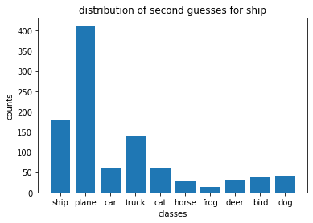

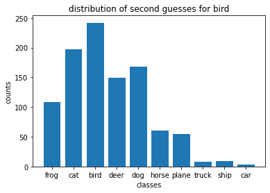

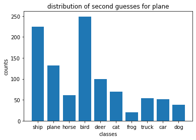

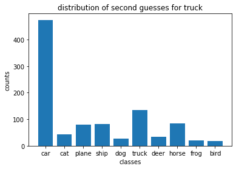

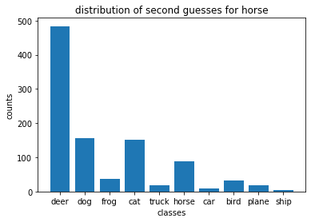

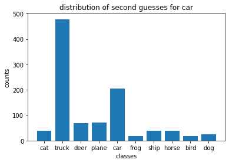

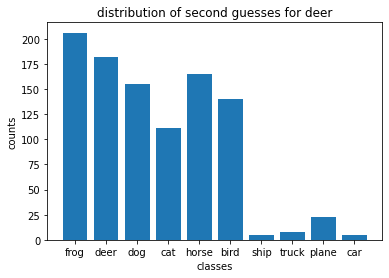

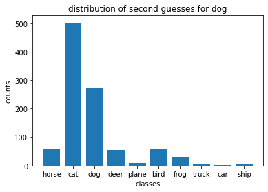

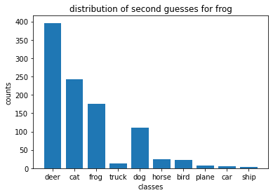

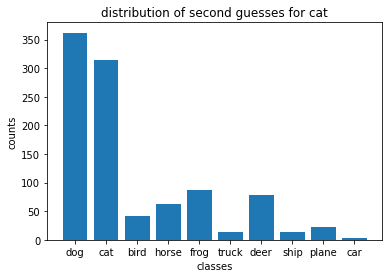

```python
# Plot the frequency distributions for second guesses for each entity
for label in second_guess:
    plt.bar(second_guess[label].keys(), second_guess[label].values())
    plt.xlabel('classes')
    plt.ylabel('counts')
    plt.title(f"distribution of second guesses for {label}")
    plt.show()
```

From this it is clear to see that our network is working in ways that we would expect. For some of the classes, the second guesses are dominated by the class that was most similar to it (attribute wise) in the clustering analysis. For example: second guesses for dog were dominated by cat, the same is true for car and truck, ship and plane, the second guess of horse is deer, and the second guess for plane is bird. One interesting note is that deer is more evenly distributed than the other classes. However, despite this the seem to be obeying the taxonomy since most of their frequency falls with other living things as opposed to nonliving things.

Although this matches our intuition we will now perform a simple statistical test.

Here we use a chisquare frequency test to determine if the frequencies of the second guesses are significantly different from uniform.

```python
# Perform Chi-Square Frequency test for each entity second guesses
for label in second_guess:
    print(f"{label}: {chisquare(list(second_guess[label].values()))[1]}")
```

```
ship: 1.780533451712974e-279
bird: 2.8348984280591647e-137
plane: 1.0955681279501463e-114
truck: 0.0
horse: 0.0
car: 0.0
deer: 4.618150368837863e-122
dog: 0.0
frog: 0.0
cat: 0.0
```

Based on this test, it's clear that the second guesses are biased towards certain categories, but this test does not give us information on how the bias is distributed. However, the frequency plots above give us qualitative information on how the distribution is biased.

# Conclusion

Some extensions that could be done to further explore this area are: (1) utilizing datasets with larger class sets to determine if dataset size impacts the taxonomic organization - datasets like ImageNet (linked above) would be particularly useful (2) using a different set of entity attributes - since attributes are the learning signal, its clear that they control the representations, so how does changing them affect the entity representations (3) Seeing if a trained attribute model can generalize well to other classification datasets (4) Seeing if a trained attribute model is useful as a base for transfer learning on other computer vision tasks - a major one being video action classification. In video action classification (or temporal action localization) the signal is much more sparse than in image classification. The tensor representation of videos are much larger and yet they still have to be mapped to single classes. Using an attribute trained model as a backbone could help boost performance. There are many more ways this project can be expanded and though I plan on expanding on this project, I'm hoping that those who have read this will be inspired to explore the possibilities

I hope that I've convinced you that area of semantic cognition in cognitive science (and cognitive science in general) has a lot to offer the field of AI. The inductive biases introduced in the form of handcrafted features could lead to more robust, human like, and explainable AI algorithms. However,if I did not convince you, I hope you enjoyed my project.

Thanks for reading!